# Perform 'Exploratory Data Analysis' on the dataset 'Global Terrorism'.

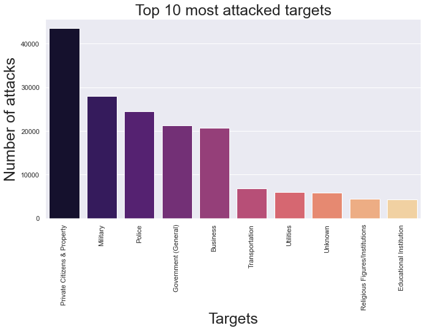

```python
# 12 most attacked targets
plt.figure(figsize = (11,6))
sns.barplot(df_data['Target_Type'].value_counts().head(10).index,df_data['Target_Type'].value_counts().head(10).values,
            palette='magma')
plt.title('Top 10 most attacked targets',fontsize=25)
plt.xlabel('Targets',fontsize=25)
plt.ylabel('Number of attacks',fontsize=25)
plt.xticks(rotation=90)
plt.show()
```

This Graph conclude: Private citizens and Property are most likely attack target for terrorist followed by Military,Police,Goverment,Business

[figure not shown]

```python
# regions with most attacks
plt.subplot(1,2,1)
sns.barplot(df_data['Region'].value_counts().index,df_data['Region'].value_counts().values,palette='flare')
plt.title('Most Attacked Regions',fontsize=25)
plt.xlabel('Regions',fontsize=25)
plt.ylabel('Number of Attacks',fontsize=25)
plt.xticks(rotation=90)


plt.subplot(1,2,2)
sns.barplot(df_data['State'].value_counts().head(15).index,df_data['State'].value_counts().head(15).values,palette='viridis')
plt.title('Top 10 Most Attacked States',fontsize=25)
plt.xlabel('States',fontsize=25)
plt.ylabel('Number of Attacks',fontsize=25)
plt.xticks(rotation=90)
plt.gcf().set_size_inches(15, 5)
```

Most attacked Region is Middle East and North Africa and then comes South Asia Most attacked state is Baghdad

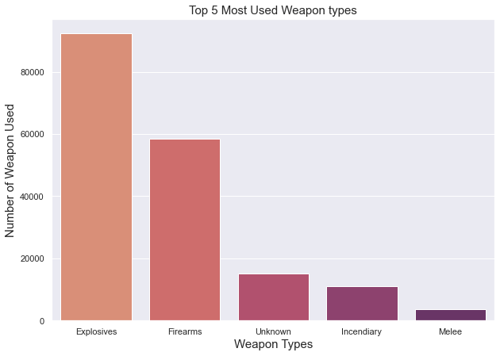

```python
# Top 10 most used weapons types in terror attacks
plt.figure(figsize=(10,7))
sns.barplot(df_data['Weapon_type'].value_counts().head(5).index,df_data['Weapon_type'].value_counts().head(5).values,palette='flare')
plt.title('Top 5 Most Used Weapon types',fontsize=15)
plt.xlabel('Weapon Types',fontsize=15)
plt.ylabel('Number of Weapon Used',fontsize=15)
```

50% of Explosives and 32% Firearms used in Terrorism activities

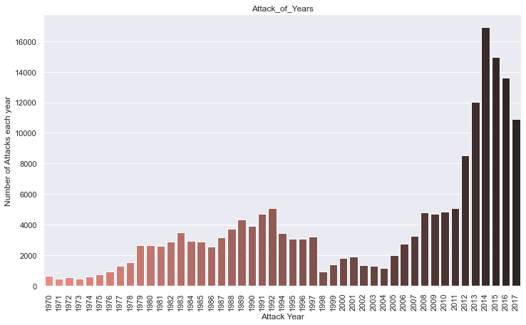

```python
x_year = df_data['Year'].unique()
y_count_years = df_data['Year'].value_counts(dropna = False).sort_index()
plt.figure(figsize = (12,7))
sns.barplot(x = x_year,
           y = y_count_years,
           palette = 'dark:salmon_r')
plt.xticks(rotation = 90)
plt.xlabel('Attack Year')
plt.ylabel('Number of Attacks each year')
plt.title('Attack_of_Years')
plt.show()
```

2014 appears to be witness of a huge terrorist attacks

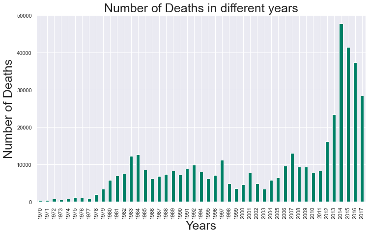

```python
plt.figure(figsize = (12,7))
df_data.groupby(['Year'])['Killed'].sum().plot(kind='bar',colormap='summer')
plt.title('Number of Deaths in different years',fontsize=25)
plt.xlabel('Years',fontsize=25)
plt.ylabel('Number of Deaths',fontsize=25)
plt.xticks(rotation=90)
plt.show()
```

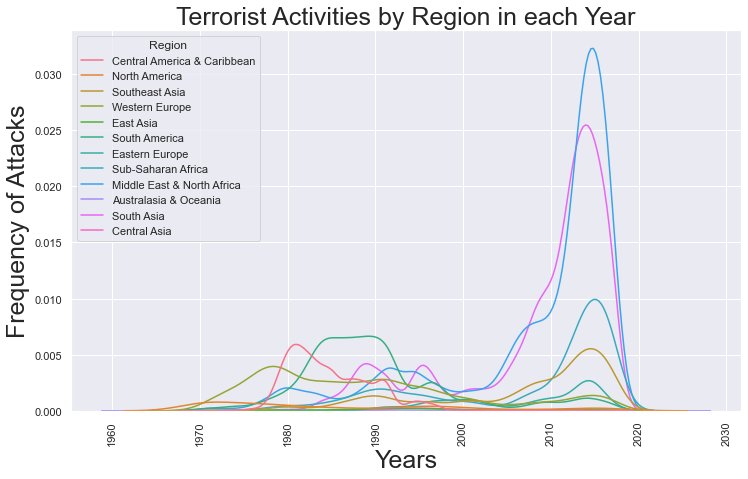

```python
plt.figure(figsize = (12,7))
sns.kdeplot(df_data['Year'], hue = df_data['Region'])
plt.title('Terrorist Activities by Region in each Year',fontsize=25)
plt.xlabel('Years',fontsize=25)
plt.ylabel('Frequency of Attacks',fontsize=25)
plt.xticks(rotation=90)
plt.show()
```

Analysis on Number of people killed and Wounded in a Particular Region

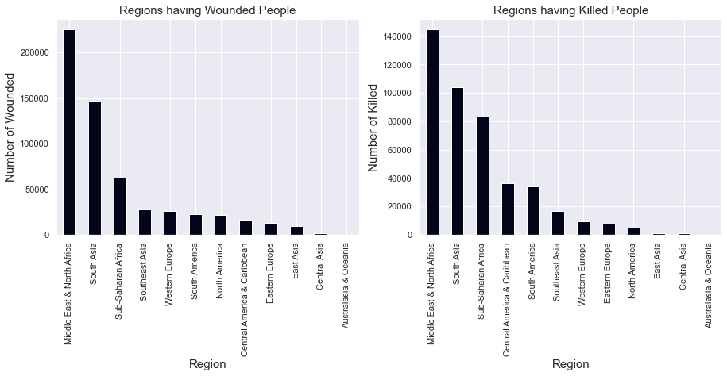

```python
plt.subplot(1,2,1)

df_data.groupby(['Region'])['Wounded'].sum().sort_values(ascending = False).plot(kind='bar',colormap='rocket')
plt.title('Regions having Wounded People',fontsize=15)
plt.xlabel('Region',fontsize=15)
plt.ylabel('Number of Wounded',fontsize=15)
plt.xticks(rotation=90)

plt.subplot(1,2,2)
df_data.groupby(['Region'])['Killed'].sum().sort_values(ascending = False).plot(kind='bar',colormap='rocket')
plt.title('Regions having Killed People',fontsize=15)
plt.xlabel('Region',fontsize=15)
plt.ylabel('Number of Killed',fontsize=15)
plt.xticks(rotation=90)
plt.gcf().set_size_inches(15, 5)
```

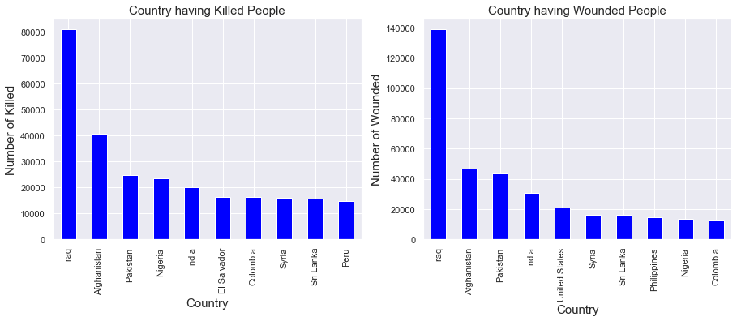

```python
plt.subplot(1,2,2)

df1=df_data.groupby(['Country'])['Wounded'].sum().sort_values(ascending = False).head(10).plot(kind='bar',colormap='winter')
plt.title('Country having Wounded People',fontsize=15)
plt.xlabel('Country',fontsize=15)
plt.ylabel('Number of Wounded',fontsize=15)
plt.xticks(rotation=90)

plt.subplot(1,2,1)
df_data.groupby(['Country'])['Killed'].sum().sort_values(ascending = False).head(10).plot(kind='bar',colormap='winter')
plt.title('Country having Killed People',fontsize=15)
plt.xlabel('Country',fontsize=15)
plt.ylabel('Number of Killed',fontsize=15)
plt.xticks(rotation=90)
plt.gcf().set_size_inches(15, 5)
```

IRAQ has the most killed and Wounded people because of Terrorism

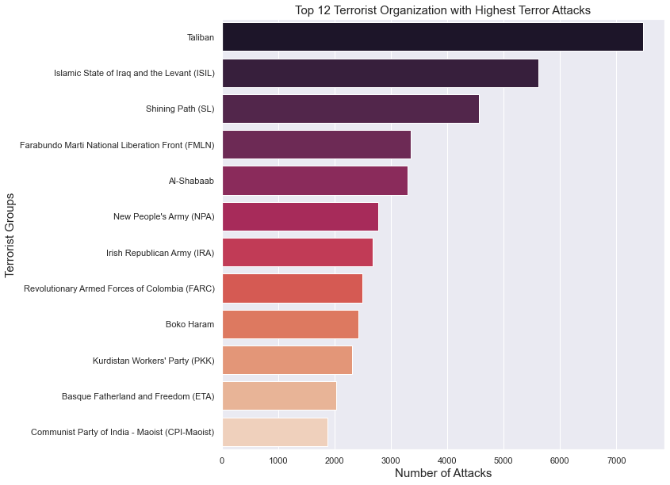

```python
#Terrorist Organisation

plt.figure(figsize=(10,10))
sns.barplot(df_data['Group'].value_counts()[1:13].values,df_data['Group'].value_counts()[1:13].index,palette='rocket')
plt.title('Top 12 Terrorist Organization with Highest Terror Attacks',fontsize=15)
plt.xlabel('Number of Attacks',fontsize=15)
plt.ylabel('Terrorist Groups',fontsize=15)
plt.show()
```

Taliban is one of the most actively Terrorist organisation

```python
df_tal = df_data[df_data.Group == 'Taliban']
```

[output not shown]

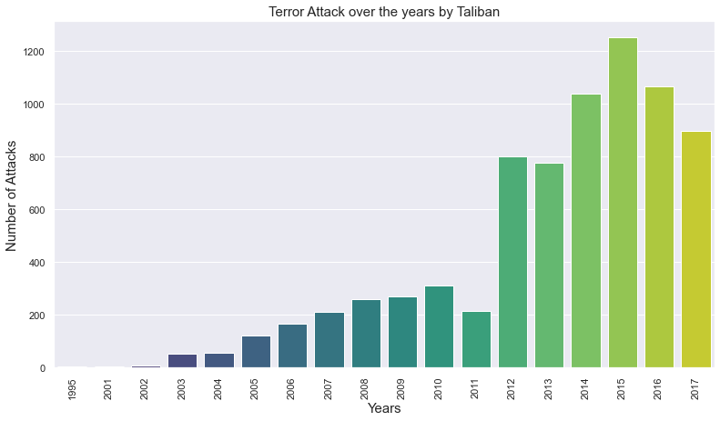

```python
# Terror Attacks by Taliban over the Years
plt.figure(figsize = (13,7))
sns.barplot(df_tal['Year'].value_counts().index,df_tal['Year'].value_counts().values, palette = 'viridis')
plt.title('Terror Attack over the years by Taliban',fontsize=15)
plt.xlabel('Years',fontsize=15)
plt.ylabel('Number of Attacks',fontsize=15)
plt.xticks(rotation= 90)
```

[figure not shown]

```python
plt.figure(figsize=(13,7))
df_data.groupby(['Year'])['Killed'].sum().plot(kind='bar',colormap='RdBu')
plt.title('People Killed by Taliban over the Years',fontsize=15)
plt.xlabel('Years',fontsize=15)
plt.ylabel('Number of people killed',fontsize=15)
plt.xticks(rotation=90)
plt.grid()
plt.show()
```